# CNN

Tao Zou

2024-01-13

# PIL

Show a gray image and a color image from <np.ndarray>.

```python
import numpy as np
import matplotlib.pyplot as plt

gray_image_np = np.random.randint(0, 256, size=(100, 100, 1), dtype=np.uint8)
color_image_np = np.random.randint(0, 256, size=(100, 100, 3), dtype=np.uint8)

plt.subplot(1, 2, 1)
plt.axis('off')
plt.imshow(gray_image_np, cmap='gray')

plt.subplot(1, 2, 2)
plt.axis('off')
plt.imshow(color_image_np)

plt.show()
```

[output not shown]

# Load Existing Classic Dataset

# LeNet

## LeNet structure code

```python
# The input image's shape is (num_channels: 1, height: 28, width: 28)
# The ouput classes number is 10
import torch
from torch import nn

model = nn.Sequential(nn.Conv2d(1, 6, kernel_size=5, padding=2), nn.Sigmoid(),
                    nn.AvgPool2d(kernel_size=2, stride=2),
                    nn.Conv2d(6, 16, kernel_size=5), nn.Sigmoid(),
                    nn.AvgPool2d(kernel_size=2, stride=2),
                    nn.Flatten(),
                    nn.Linear(16 * 5 * 5, 120), nn.Sigmoid(),
                    nn.Linear(120, 84), nn.Sigmoid(),
                    nn.Linear(84, 10))
```

`nn.Conv2d(in_channels, out_channels, kernel_size, stride, padding, dilation, groups, bias=True, padding_mode='zeros')`

- *in_channels*: represent the number of feature images(channels) in the input layer;
- *out_channels*: represents the number of channels in the output layer, meanwhile, it is the number of convolutional kernels;
- *kernel_size=5*: means that each kernel’s pixel is 5×5.

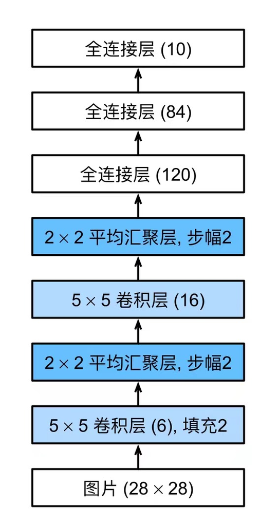

## Fashion-MNIST Data Loading code

```python
import torch
import torch.nn as nn
import torchvision
import torchvision.transforms as transforms
import numpy as np

transform = transforms.Compose(
    [transforms.Resize((28, 28)),
     transforms.ToTensor(),
     transforms.Normalize([0.5], [0.5])])

train_data = torchvision.datasets.FashionMNIST(root='./data', train=True, download=True, transform=transform)
test_data = torchvision.datasets.FashionMNIST(root='./data', train=False, download=True, transform=transform)
```

## LeNet training code

```python
device = "cuda" if torch.cuda.is_available() else "cpu"

def init_weights(m):
    if type(m) == nn.Linear or type(m) == nn.Conv2d:
        nn.init.xavier_uniform_(m.weight)
model.apply(init_weights)

num_epochs = 30
batch_size = 128
lr = 0.3
model.to(device)
criterion = nn.CrossEntropyLoss(reduction='mean')
optimizer = torch.optim.SGD(model.parameters(), lr=lr, weight_decay=0.05)

train_loader = torch.utils.data.DataLoader(train_data, batch_size=batch_size, shuffle=True, num_workers=2)
val_loader = torch.utils.data.DataLoader(test_data, batch_size=batch_size, shuffle=False, num_workers=2)

for epoch in range(num_epochs):
    model.train()
    train_loss = 0
    for batch_features, batch_labels in train_loader:
        optimizer.zero_grad()
        batch_features, batch_labels = batch_features.to(device), batch_labels.to(device)
        train_outputs = model(batch_features)
        loss = criterion(train_outputs, batch_labels)
        train_loss += loss.item()
        loss.backward()
        optimizer.step()
    train_loss /= len(train_loader)

    if (epoch + 1) % 2 == 0:
        model.eval()
        true_label, pred_label = [], []
        val_loss = 0
        with torch.no_grad():
            for batch_features, batch_labels in val_loader:
                batch_features, batch_labels = batch_features.to(device), batch_labels.to(device)
                val_outputs = model(batch_features)
                loss = criterion(val_outputs, batch_labels)
                true_label.extend(batch_labels.cpu().numpy().reshape(-1))
                pred_label.extend(np.argmax(val_outputs.cpu().numpy(), axis=1))
                val_loss += loss.item()
        val_accuracy = np.mean(np.array(true_label) == np.array(pred_label))
        val_loss /= len(val_loader)
        print('epoch {}/{} | train loss: {:.4f}, val loss: {:.4f} | Accuracy: {:.2f}'.format(epoch+1, num_epochs, train_loss, val_loss, val_accuracy))
```

[output not shown]

The training result can reach an accuracy of $87\%$.

# AlexNet

## code

```python
# The input image's shape is (num_channels: 1, height: 224, width: 224)
# The ouput classes number is 10
model = nn.Sequential(
    nn.Conv2d(1, 96, kernel_size=11, stride=4, padding=1), nn.ReLU(),
    nn.MaxPool2d(kernel_size=3, stride=2),
    nn.Conv2d(96, 256, kernel_size=5, padding=2), nn.ReLU(),
    nn.MaxPool2d(kernel_size=3, stride=2),
    nn.Conv2d(256, 384, kernel_size=3, padding=1), nn.ReLU(),
    nn.Conv2d(384, 384, kernel_size=3, padding=1), nn.ReLU(),
    nn.Conv2d(384, 256, kernel_size=3, padding=1), nn.ReLU(),
    nn.MaxPool2d(kernel_size=3, stride=2),
    nn.Flatten(),
    nn.Linear(6400, 4096), nn.ReLU(),
    nn.Dropout(0.5),
    nn.Linear(4096, 4096), nn.ReLU(),
    nn.Dropout(0.5),
    nn.Linear(4096, 10)
)
```

The *in_channels* of the first layer is 1 instead of 3 in order to train Fashion-MINST data set, which includes gray-scale images.

The model training code is the same with the code in LeNet trainging code. Because this is a deep convolutional network, perhaps I should try a smaller learning rate. And the final accuracy can reach $92\%$.

## Batch normalization

Batch normalization layer can constrain the batch data in network’s dataflow, alleviate the problem of gradient vanishing, and make deep networks converge more easily. It is applied between “affine transformation” and “activation function”.

The normalization formula is slightly different from the common one.

$$BN(\boldsymbol{x})=\gamma\cdot\frac{\boldsymbol{x}-E(\boldsymbol{x})}{\sqrt{Var(\boldsymbol{x})}}+\beta\\
E(\boldsymbol{x})=\frac{1}{n}\sum_{i=1}^n\boldsymbol{x}\\
Var(\boldsymbol{x})=\frac{1}{n}\sum_{i=1}^n\big{(}\boldsymbol{x}-E(\boldsymbol{x})\big{)}^2+\epsilon$$

$\gamma$ and $\beta$ are parameters that needed to be learned by the model.

```python
# AlexNet using batch normalization
model = nn.Sequential(
    nn.Conv2d(1, 96, kernel_size=11, stride=4, padding=1), nn.BatchNorm2d(96), nn.ReLU(),
    nn.MaxPool2d(kernel_size=3, stride=2),
    nn.Conv2d(96, 256, kernel_size=5, padding=2), nn.BatchNorm2d(256), nn.ReLU(),
    nn.MaxPool2d(kernel_size=3, stride=2),
    nn.Conv2d(256, 384, kernel_size=3, padding=1), nn.BatchNorm2d(384), nn.ReLU(),
    nn.Conv2d(384, 384, kernel_size=3, padding=1), nn.BatchNorm2d(384), nn.ReLU(),
    nn.Conv2d(384, 256, kernel_size=3, padding=1), nn.BatchNorm2d(256), nn.ReLU(),
    nn.MaxPool2d(kernel_size=3, stride=2),
    nn.Flatten(),
    nn.Linear(6400, 4096), nn.BatchNorm1d(4096), nn.ReLU(),
    nn.Dropout(0.5),
    nn.Linear(4096, 4096), nn.BatchNorm1d(4096), nn.ReLU(),
    nn.Dropout(0.5),
    nn.Linear(4096, 10)
)
```

# ResNet

## A ResNet block

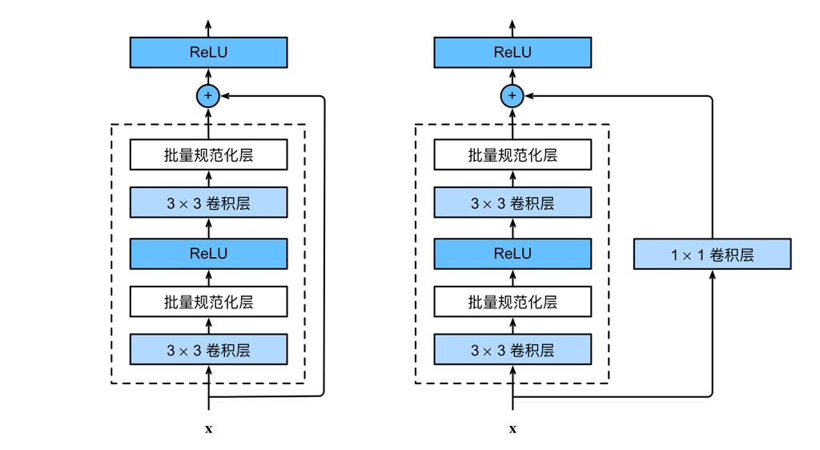

```python
import torch.nn as nn
import torch.nn.functional as F
import torch

class Residual(nn.Module):
    def __init__(self, input_channels, num_channels, use_1x1conv=False, strides=1):
        super().__init__()
        self.conv1 = nn.Conv2d(input_channels, num_channels, kernel_size=3, padding=1, stride=strides)
        self.conv2 = nn.Conv2d(num_channels, num_channels, kernel_size=3, padding=1)

        if use_1x1conv:
            self.conv3 = nn.Conv2d(input_channels, num_channels, kernel_size=1, stride=strides)
        else:
            self.conv3 = None

        self.bn1 = nn.BatchNorm2d(num_channels)
        self.bn2 = nn.BatchNorm2d(num_channels)

    def forward(self, X):
        Y = F.relu(self.bn1(self.conv1(X)))
        Y = self.bn2(self.conv2(Y))
        if self.conv3 is not None:
            X = self.conv3(X)
        Y += X
        return F.relu(Y)
```

## ResNet-18

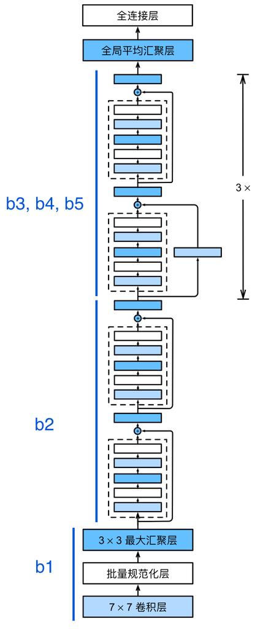

```python
# The input image's shape is (num_channels: 1, height: 224, width: 224)
# The ouput classes number is 10
def resnet_block(input_channels, num_channels, num_residuals, first_block=False):
    blk = []
    for i in range(num_residuals):
        if i == 0 and not first_block:
            '''
            The first block of two-blocks structures(b3, b4, b5) includes channel increasing(use_1x1conv=True)
            and pixel decreasing(stride=2).
            b2 is the first two-blocks structure which doesn't include channel increasing and pixel decreasing.
            '''
            blk.append(Residual(input_channels, num_channels, use_1x1conv=True, strides=2))
        else:
            blk.append(Residual(num_channels, num_channels))
    return blk

b1 = nn.Sequential(
    nn.Conv2d(1, 64, kernel_size=7, stride=2, padding=3),
    nn.BatchNorm2d(64), nn.ReLU(),
    nn.MaxPool2d(kernel_size=3, stride=2, padding=1)
)
b2 = nn.Sequential(*resnet_block(64, 64, 2, first_block=True))
b3 = nn.Sequential(*resnet_block(64, 128, 2))
b4 = nn.Sequential(*resnet_block(128, 256, 2))
b5 = nn.Sequential(*resnet_block(256, 512, 2))
model = nn.Sequential(
    b1, b2, b3, b4, b5,
    nn.AdaptiveAvgPool2d((1, 1)),
    nn.Flatten(), nn.Linear(512, 10)
)
```

The training result can reach an accuracy of $91\%$.

## Dataflow

```python
X = torch.randn(1, 1, 224, 224)
for layer in model:
    X = layer(X)
    print(layer.__calss__.__name__, 'output shape: \t', X.shape)
```

[output not shown]

# Conv3d

## Self-designed model

```python
import torch
import torch.nn as nn

# The input image's shape is (num_channels: 3, frames: 4, height: 224, width: 224)
# The ouput classes number is 10
class VideoClassifier(nn.Module):
    def __init__(self, num_classes):
        super(VideoClassifier, self).__init__()

        self.conv_layers = nn.Sequential(
            nn.Conv3d(3, 32, kernel_size=3, stride=1, padding=1),
            nn.ReLU(),
            nn.MaxPool3d(kernel_size=2, stride=2),

            nn.Conv3d(32, 64, kernel_size=3, stride=1, padding=1),
            nn.ReLU(),
            nn.MaxPool3d(kernel_size=2, stride=2),
        )

        self.fc_layers = nn.Sequential(
            nn.Flatten(),

            nn.Linear(64 * 1 * 56 * 56, 1024),
            nn.ReLU(),
            nn.Dropout(0.5),

            nn.Linear(1024, 512),
            nn.ReLU(),
            nn.Dropout(0.5),

            nn.Linear(512, num_classes),
        )

    def forward(self, x):
        x = self.conv_layers(x)
        x = x.view(x.size(0), -1)
        x = self.fc_layers(x)
        return x

model = VideoClassifier(num_classes=15)
```

## ResNet18-3d

```python
from torchvision.models.video import r3d_18

num_classes = 10
model = r3d_18(pretrained=True)
model.fc = nn.Linear(512, num_classes)
```

# CNN & RNN

The code below shows ResNet-18 + LSTM structure model.

```python
import torch
import torch.nn as nn
import torch.nn.functional as F

class Residual(nn.Module):
    def __init__(self, input_channels, num_channels, use_1x1conv=False, strides=1):
        super().__init__()
        self.conv1 = nn.Conv2d(input_channels, num_channels, kernel_size=3, padding=1, stride=strides)
        self.conv2 = nn.Conv2d(num_channels, num_channels, kernel_size=3, padding=1)

        if use_1x1conv:
            self.conv3 = nn.Conv2d(input_channels, num_channels, kernel_size=1, stride=strides)
        else:
            self.conv3 = None

        self.bn1 = nn.BatchNorm2d(num_channels)
        self.bn2 = nn.BatchNorm2d(num_channels)

    def forward(self, X):
        Y = F.relu(self.bn1(self.conv1(X)))
        Y = self.bn2(self.conv2(Y))
        if self.conv3 is not None:
            X = self.conv3(X)
        Y += X
        return F.relu(Y)

def resnet_block(input_channels, num_channels, num_residuals, first_block=False):
    blk = []
    for i in range(num_residuals):
        if i == 0 and not first_block:
            blk.append(Residual(input_channels, num_channels, use_1x1conv=True, strides=2))
        else:
            blk.append(Residual(num_channels, num_channels))
    return blk

b1 = nn.Sequential(
    nn.Conv2d(3, 64, kernel_size=7, stride=2, padding=3),
    nn.BatchNorm2d(64), nn.ReLU(),
    nn.MaxPool2d(kernel_size=3, stride=2, padding=1)
)
b2 = nn.Sequential(*resnet_block(64, 64, 2, first_block=True))
b3 = nn.Sequential(*resnet_block(64, 128, 2))
b4 = nn.Sequential(*resnet_block(128, 256, 2))
b5 = nn.Sequential(*resnet_block(256, 512, 2))
CNN_model = nn.Sequential(
    b1, b2, b3, b4, b5,
    nn.AdaptiveAvgPool2d((1, 1)),
    nn.Flatten()
)

class CNNtoRNN(nn.Module):
    def __init__(self, num_classes, rnn_hidden_size, num_layers=1):
        super(CNNtoRNN, self).__init__()

        self.cnn = CNN_model
        cnn_output_features = 512

        self.rnn_hidden_size = rnn_hidden_size
        self.num_layers = num_layers
        self.rnn = nn.LSTM(input_size=cnn_output_features,
                           hidden_size=self.rnn_hidden_size,
                           num_layers=self.num_layers,
                           batch_first=True)
        self.fc = nn.Linear(self.rnn_hidden_size, num_classes)

    def forward(self, x):
        # x's shape is (batch_size, win_len, channels, height, width)
        batch_size, win_len, channels, height, width = x.shape
        '''
        CNN:
        c_in's shape is (batch_size*win_len, channels, height, width)
        c_out's shape is (batch_size*win_len, cnn_output_features)
        '''
        c_in = x.view(batch_size * win_len, channels, height, width)
        c_out = self.cnn(c_in)

        '''
        RNN:
        r_in's shape is (batch_size, win_len, cnn_output_features)
        r_out(batch_size, win_len, num_hiddens) is all of the hidden states
        hn(1, batch_size, num_hiddens) is the last hidden state
        r_out[:, -1, :].squeeze(1) is hn.squeeze(0)
        cn(1, batch_size, num_hiddens) is LSTM's memory cell
        '''
        r_in = c_out.view(batch_size, win_len, -1)
        r_out, (hn, cn) = self.rnn(r_in)
        r_out = r_out[:, -1, :]
        output = self.fc(r_out)

        return output

model = CNNtoRNN(num_classes=15, rnn_hidden_size=32)

input_tensor = torch.rand(16, 10, 3, 224, 224) # (batch_size, frames, channels, height, width)
output = model(input_tensor)
print(output.shape)  # output's shape is (batch_size, num_classes)
```

[output not shown]

As to video classification mission, CNN&RNN has a worse effect than CNN3d.